# A. INTRODUCTION

# TUGAS PRAKTIK 2

Diketahui terdapat potongan kode berikut :

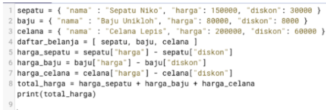

Buatlah jadi sederhana!

```python
sepatu = { "nama" : "Sepatu Niko", "harga": 150000, "diskon": 30000 }
baju = { "nama" : "Baju Unikloh", "harga": 80000, "diskon": 8000 }
celana = { "nama" : "Celana Lepis", "harga": 200000, "diskon": 60000 }
harga_sepatu = sepatu["harga"] - sepatu["diskon"]
harga_baju = baju["harga"] - baju["diskon"]
harga_celana = celana["harga"] - celana["diskon"]
total_harga = (harga_sepatu + harga_baju + harga_celana) * 1.1
print(total_harga)
```

```
365200.00000000006
```

.

.

# F. CONDITIONING FOR DECISION

Layaknya bahasa pemrograman lainnya, bahasa pemrograman Python menyediakan statemen desisi (decision statement) untuk berinteraksi dengan variabel bertipe boolean dan operator logika. Statemen desisi dalam Python dapat dituliskan dengan menggunakan format berikut,

```
if conditions:
do_action_1
...
do_action_n
```

Dengan --conditions-- berisikan operator yang mengembalikan nilai kebenaran; ataupun beberapa operator yang mengembalikan nilai kebenaran, yang digabungkan dengan operator logika. Melalui sebuah statemen desisi (if statement), --do_action_1-- sampai dengan --do_action_n-- akan dijalankan saat --conditions-- bernilai True.

Dalam menuliskan serangkaian aksi (--do_action_1--, ... , --do_action_n--) dalam sebuah statemen if, kita harus mengemas setiap aksi dalam sebuah blok dengan menambahkan indentasi (jorokan) dari pada aksi.

Tambahan :

Untuk melengkapi sebuah statement if, kita bisa menambahkan satu ataupun lebih statemen desisi elif, untuk melakukan pengecekan kondisi lainnya, saat kondisi dalam statement if atau elif di atasnya tidak terpenuhi.

```python
#Example

# Statement if
x = 4
if x % 2 == 0: # jika sisa bagi x dengan 2 sama dengan 0
    print("x habis dibagi dua") # statemen aksi lebih menjorok ke dalam
# Statement if ... elif ... else
x = 7
if x % 2 == 0: # jika sisa bagi x dengan 2 sama dengan 0
    print("x habis dibagi dua")
elif x % 3 == 0: # jika sisa bagi x dengan 3 sama dengan 0
    print("x habis dibagi tiga")
elif x % 5 == 0: # jika sisa bagi x dengan 5 sama dengan 0
    print("x habis dibagi lima")
else:
    print("x tidak habis dibagi dua, tiga ataupun lima")
```

```
x habis dibagi dua
x tidak habis dibagi dua, tiga ataupun lima
```

Dari yang kita pelajari pada bagian awal dari statemen desisi, operator desisi juga dapat digunakan dengan operator logika.

Sebagai catatan tambahan, kita juga belajar bahwa aksi dalam sebuah desisi statemen dapat dituliskan desisi statemen tambahan (lainnya) yang dikenal dengan istilah nested if.

```python
#Example Logika
jam = 13
if jam >=5 and jam <12: # selama jam di antara 5 s.d. 12
    print("Selamat pagi!")
elif jam >=12 and jam <17: # selama jam di antara 12 s.d. 17
    print("Selamat siang!")
elif jam >=17 and jam <19: # selama jam di antara 17 s.d. 19
    print("Selamat sore!")
else: # selain kondisi di atas
    print("Selamat malam!")
```

```
Selamat siang!
```

```python
#Example nested

jam = 13
hari = 'senin'
if hari == 'senin' :
    if jam >=5 and jam <12:
        print("Selamat pagi!")
    elif jam >=12 and jam <17:
        print("Selamat siang!")
    elif jam >=17 and jam <19:
        print("Selamat sore!")
else:
    print("Ini bukan hari senin!")
```

```
Selamat siang!
```

# TUGAS PRAKTIK 3

### Kasus 1

Hitunglah tagihan pembayaran dengan kasus berikut :

“Aksara, kantor kita akan merilis penawaran baru terkait jasa pembuatan data warehouse. Bisa tolong kembangkan kalkulatormu untuk menghitung tagihan pembayaran? Soalnya selama ini kita masih manual,” jelas Senja sembari memberikan contoh nota tagihan kantor.

Aku belum mengiyakan karena sedikit ragu. Mengingat sebelumnya aku sempat salah. Tapi dalam hati aku berkata, pasti bisa! Kali ini aku harus mampu membuat kalkulator lebih rumit.

Solusi yang terlintas dalam bayanganku: Kalkulator ini harus dapat menghitung subtotal setiap jasa yang diambil dari kolom harga/ hari dan total hari dari setiap jasa. Ternyata Senja juga memikirkan hal yang sama dengan instruksinya yang sangat membantu.

Tagihan :

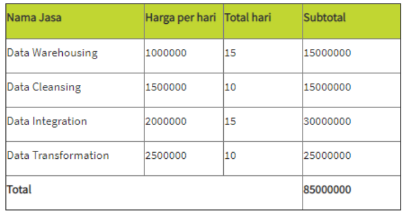

```python
tagihan_ke = 'Mr. Yoyo'
warehousing = { 'harga_harian': 1000000, 'total_hari':15 }
cleansing = { 'harga_harian': 1500000, 'total_hari':10 }
integration = { 'harga_harian':2000000, 'total_hari':15 }
transform = { 'harga_harian':2500000, 'total_hari':10 }
sub_warehousing = warehousing['harga_harian'] * warehousing['total_hari']
sub_cleansing = cleansing['harga_harian'] * cleansing['total_hari']
sub_integration = integration['harga_harian'] * integration['total_hari']
sub_transform = transform['harga_harian'] * transform['total_hari']
total_harga = sub_warehousing + sub_cleansing + sub_integration + sub_transform
print("Tagihan kepada:")
print(tagihan_ke)
print("Selamat pagi, anda harus membayar tagihan sebesar:")
print(total_harga)
```

```
Tagihan kepada:
Mr. Yoyo
Selamat pagi, anda harus membayar tagihan sebesar:
85000000
```

### Kasus 2

Aku menunjukkan potongan kode dan hasil dari kalkulator yang telah aku buat ke Senja yang sudah berhasil menampilkan kalimat:

Selamat pagi, Anda harus membayar tagihan sebesar:

Kulihat kedua alis Senja bertaut, ini pertanda kodeku pasti ada yang keliru. “Kalau kamu hanya memasukkan perintah ‘selamat pagi’ seakan kalau tagihan ini dikirim hanya saat pagi, padahal bisa kapan saja sesuai kebutuhan,” komentar Senja. Begini, jam pengiriman email kantor kita mulai dari 6 pagi sampai 9 malam.

Tugas: Tolong masukkan variabel keterangan waktu tersebut di kodemu. Lalu, diatur dengan detail berikut:

Diatas jam 07 malam adalah salam 'selamat malam'

Diatas jam 05 sore adalah salam 'selamat sore'

Diatas jam 12 siang, adalah 'selamat siang'

dan selain itu 'selamat pagi'

“Oh, oke. Paham,” sahutku sembari merevisi. Saran yang bagus, kedepannya aku harus berpikir kritis.

```python
jam = 17
tagihan_ke = 'Mr. Yoyo'
warehousing = { 'harga_harian': 1000000, 'total_hari':15 }
cleansing = { 'harga_harian': 1500000, 'total_hari':10 }
integration = { 'harga_harian':2000000, 'total_hari':15 }
transform = { 'harga_harian':2500000, 'total_hari':10 }
sub_warehousing = warehousing['harga_harian']*warehousing['total_hari']
sub_cleansing = cleansing['harga_harian']*cleansing['total_hari']
sub_integration = integration['harga_harian']*integration['total_hari']
sub_transform = transform['harga_harian']*transform['total_hari']
total_harga = sub_warehousing+sub_cleansing+sub_integration+sub_transform
print("Tagihan kepada:")
print(tagihan_ke)
if jam > 19:
    print("Selamat malam, anda harus membayar tagihan sebesar:")
elif jam > 17:
    print("Selamat sore, anda harus membayar tagihan sebesar:")
elif jam > 12:
    print("Selamat siang, anda harus membayar tagihan sebesar:")
else:
    print("Selamat pagi, anda harus membayar tagihan sebesar:")
print(total_harga)
```

```
Tagihan kepada:
Mr. Yoyo
Selamat siang, anda harus membayar tagihan sebesar:
85000000
```

.

.

# G. LOOPING

Secara umum, Python mengeksekusi program baris perbaris. Mulai dari baris satu, dua, dan seterusnya. Ada kalanya, kita perlu mengeksekusi satu baris atau satu blok kode program beberapa kali. Hal ini disebut dengan perulangan atau biasa disebut looping atau iterasi. Untuk lebih jelasnya perhatikan gambar berikut:

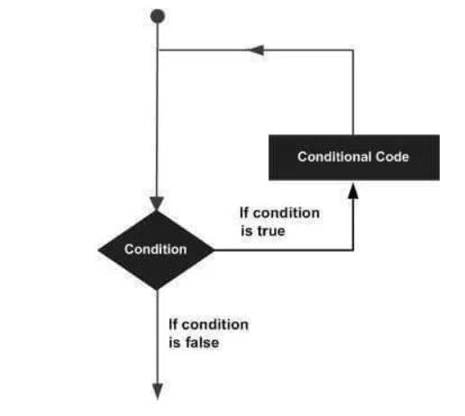

Pada gambar bisa dilihat bahwa perulangan juga memerlukan tes kondisi. Bila hasil tes kondisi True, maka blok kode kembali dieksekusi. Tapi jika False, maka keluar dari perulangan.

Di python, perulangan bisa dilakukan dengan dua cara atau metode, yaitu:

- Menggunakan for
- Menggunakan while

## G1. For Loops

Perulangan dengan menggunakan for memiliki sintaks seperti berikut:

```
for var in sequence:
    body of for
```

var adalah variabel yang digunakan untuk penampung sementara nilai dari sequence pada saat terjadi perulangan. Sequence adalah tipe data berurut seperti string, list, dan tuple.

Perulangan terjadi sampai looping mencapai elemen atau anggota terakhir dari sequence. Bila loop sudah sampai ke elemen terakhir dari sequence, maka program akan keluar dari looping.

```python
# Program untuk menemukan jumlah bilangan dalam satu list

# List number
numbers = [7, 5, 9, 8, 4, 2, 6, 4, 1]

# variablel untuk menyimpan jumlah

sum = 0

# iterasi
for each in numbers:
    sum = sum + each

# Output: Jumlah semuanya: 46
print("Jumlah semuanya:", sum)
```

```
Jumlah semuanya: 46
```

## G2. Fungsi range()

Fungsi range() dapat digunakan untuk menghasilkan deret bilangan. range(10) akan menghasilkan bilangan dari 0 sampai dengan 9 (10 bilangan).

Kita juga bisa menentukan batas bawah, batas atas, dan interval dengan format range(batas bawah, batas atas, interval).Bila interval dikosongkan, maka nilai default 1 yang akan digunakan.

Fungsi range tidak menyimpan semua nilai dalam memori secara langsung. Ia hanya akan mengingat batas bawah, batas atas, dan interval dan membangkitkan hasilnya satu persatu hanya bila dipanggil. Untuk membuat fungsi ini langsung menampilkan semua item, kita bisa menggunakan fungsi list(). Untuk jelasnya perhatikan contoh berikut:

```
# Output: range(0,10)
print(range(10))

# Output: [0, 1, 2, 3, 4, 5, 6, 7, 8, 9]
print(list(range(10))

# Output: [2, 3, 4, 5, 6, 7]
print(list(range(2,8))

# Output: [2, 5, 8, 11, 14, 17]
print(list(range(2, 20, 3)
```

Kita bisa menggunakan fungsi range() dalam perulangan menggunakan for untuk iterasi bilangan berurut. Hal ini dengan cara mengkombinasikan fungsi range() dengan fungsi len() . Fungsi len() berfungsi untuk mendapatkan panjang atau jumlah elemen suatu data sekuensial atau berurut.

```python
# Program untuk iterasi list menggunakan pengindeksan

mapel = ['matematika', 'fisika', 'kimia']

# iterasi list menggunakan indeks
for i in range(len(mapel)):
    print("Saya suka", mapel[i])
```

```
Saya suka matematika
Saya suka fisika
Saya suka kimia
```

## G3. While Loops

Perulangan menggunakan while akan menjalankan blok pernyataan terus menerus selama kondisi bernilai benar.

Adapun sintaks dari perulangan menggunakan while adalah:

```
while expression:
    statement (s)
```

Di sini, statement (s) bisa terdiri dari satu baris atau satu blok pernyataan. Expression merupakan ekspresi atau kondisi apa saja, dan untuk nilai selain nol dianggap True. Iterasi akan terus berlanjut selama kondisi benar. Bila kondisi salah, maka program akan keluar dari while dan lanjut ke baris pernyataan di luar while.

Adapun diagram alir while adalah seperti gambar berikut:

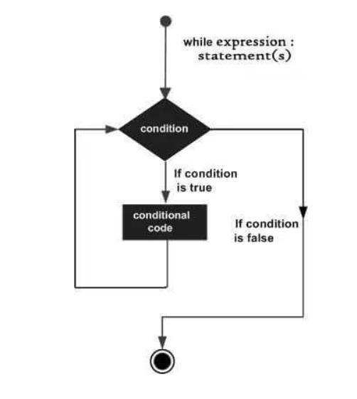

Perhatikan bahwa bila kondisi yang diuji bernilai salah, maka loop tidak akan pernah dieksekusi.

```python
count = 0
while (count < 5):
    print('The count is:', count)
    count = count + 1
print('Good bye!')
```

```
The count is: 0
The count is: 1
The count is: 2
The count is: 3
The count is: 4
Good bye!
```

Di sini, blok pernyataan print('The count is:', count), dijalankan terus selama count masih lebih kecil dari 5. Count ditambah 1 setiap kali iterasi. Pada saat nilai count mencapai 5, maka kondisi menjadi False dan program keluar dari looping while dan melanjutkan baris selanjutnya yaitu print("Good bye").

## G4. Infinite Loop

ebuah kondisi dimana loop selalu benar dan tidak pernah salah disebut loop tidak terbatas (infinite loop). Terkadang hal ini menjadi masalah. Tapi sering juga infinite loop berguna, misalnya untuk program client/server dimana server perlu menjaga komunikasi tetap hidup dan tidak terputus.

Pada contoh program while di atas, bila kita lupa menuliskan kode count = count + 1, maka akan jadi infinite loop. Hasilnya akan jadi seperti berikut:

```
The count is: 0
The count is: 0
The count is: 0
The count is: 0
The count is: 0

Traceback (most recent call last):
File "<pyshell#4>", line 2, in <module>
print('The count is:', count)
File "C:\Python34\lib\idlelib\PyShell.py", line 1344, in write
return self.shell.write(s, self.tags)
KeyboardInterrupt
```

Kita perlu menekan CTRL+C untuk menghentikan program.

## G5. Kendali Looping

Looping umumnya akan berhenti bila kondisi sudah bernilai salah. Akan tetapi, seringkali kita perlu keluar dari looping di tengah jalan tergantung keperluan. Hal ini bisa kita lakukan dengan menggunakan kata kunci break dan continue.

Statement break memaksa program keluar dari blok looping di tengah jalan. Sedangkan statement continue menyebabkan program langsung melanjut ke step / interval berikutnya dan mengabaikan (skip) baris kode di bawahnya (yang satu blok). Jelasnya perhatikan contoh berikut:

```python
# contoh penggunaan statement break
for letter in "Programming":
    if letter == "g":
        break
    print("Huruf sekarang:", letter)
print("Good bye")
```

```
Huruf sekarang: P
Huruf sekarang: r
Huruf sekarang: o
Good bye
```

Bila pada program di atas kita ganti kode break menjadi continue, maka hasilnya akan jadi seperti berikut:

```
Huruf sekarang: P
Huruf sekarang: r
Huruf sekarang: o
Huruf sekarang: r
Huruf sekarang: a
Huruf sekarang: m
Huruf sekarang: m
Huruf sekarang: i
Huruf sekarang: n
Good bye
```

Perhatikan bahwa huruf g tidak pernah ditampilkan karena diabaikan karena kode continue.

## G6. While Else

Python mendukung penggunaan else sebagai pasangan dari while. Blok pernyataan else hanya akan dieksekusi bila kondisi while bernilai salah.

```python
count = 0
while (count < 5):
    print(count, "kurang dari 5")
    count = count + 1
else:
    print(count, "tidak kurang dari 5")
```

```
0 kurang dari 5
1 kurang dari 5
2 kurang dari 5
3 kurang dari 5
4 kurang dari 5
5 tidak kurang dari 5
```

# TUGAS PRAKTIK 4

Aku diminta tolong Senja untuk menghitung tagihan pembayaran karena saat ini prosesnya masih manual.

Tugas:

“Aksara, kantor kita akan merilis penawaran baru terkait jasa pembuatan data warehouse. Bisa tolong kembangkan kalkulatormu untuk menghitung tagihan pembayaran? Soalnya selama ini kita masih manual,” jelas Senja sembari memberikan contoh nota tagihan kantor.

Aku belum mengiyakan karena sedikit ragu. Mengingat sebelumnya aku sempat salah. Tapi dalam hati aku berkata, pasti bisa! Kali ini aku harus mampu membuat kalkulator lebih rumit.

Solusi yang terlintas dalam bayanganku: Kalkulator ini harus dapat menghitung subtotal setiap jasa yang diambil dari kolom harga/ hari dan total hari dari setiap jasa. Ternyata Senja juga memikirkan hal yang sama dengan instruksinya yang sangat membantu.

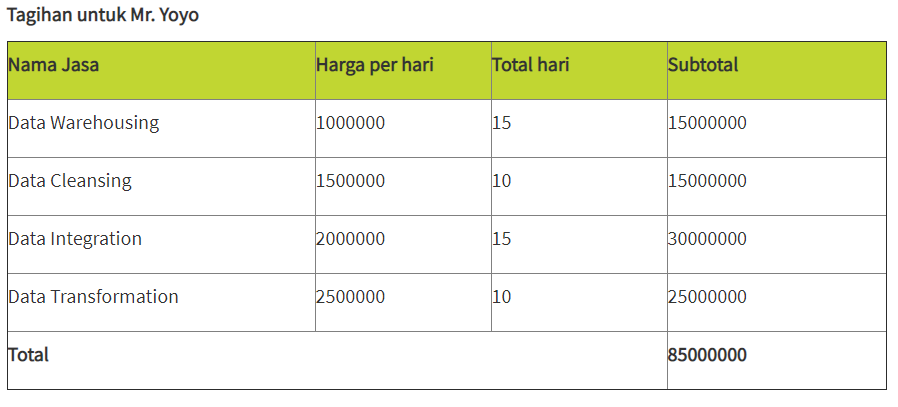

```python
tagihan_ke = 'Mr. Yoyo'
warehousing = { 'harga_harian': 1000000, 'total_hari':15 }
cleansing = { 'harga_harian': 1500000, 'total_hari':10 }
integration = { 'harga_harian':2000000, 'total_hari':15 }
transform = { 'harga_harian':2500000, 'total_hari':10 }
sub_warehousing = warehousing['harga_harian'] * warehousing['total_hari']
sub_cleansing = cleansing['harga_harian'] * cleansing['total_hari']
sub_integration = integration['harga_harian'] * integration['total_hari']
sub_transform = transform['harga_harian'] * transform['total_hari']
total_harga = sub_warehousing + sub_cleansing + sub_integration + sub_transform
print("Tagihan kepada:")
print(tagihan_ke)
print("Selamat pagi, anda harus membayar tagihan sebesar:")
print(total_harga)
```

```
Tagihan kepada:
Mr. Yoyo
Selamat pagi, anda harus membayar tagihan sebesar:
85000000
```

# TUGAS PRAKTIK 5

Aku menunjukkan potongan kode dan hasil dari kalkulator yang telah aku buat ke Senja yang sudah berhasil menampilkan kalimat:

Selamat pagi, Anda harus membayar tagihan sebesar:

Kulihat kedua alis Senja bertaut, ini pertanda kodeku pasti ada yang keliru.

“Kalau kamu hanya memasukkan perintah ‘selamat pagi’ seakan kalau tagihan ini dikirim hanya saat pagi, padahal bisa kapan saja sesuai kebutuhan,” komentar Senja. Begini, jam pengiriman email kantor kita mulai dari 6 pagi sampai 9 malam.

Tugas: Tolong masukkan variabel keterangan waktu tersebut di kodemu. Lalu, diatur dengan detail berikut:

- Diatas jam 07 malam adalah salam 'selamat malam'
- Diatas jam 05 sore adalah salam 'selamat sore'
- Diatas jam 12 siang, adalah 'selamat siang'
- dan selain itu 'selamat pagi'

“Oh, oke. Paham,” sahutku sembari merevisi. Saran yang bagus, kedepannya aku harus berpikir kritis.

```python
jam = 17
tagihan_ke = 'Mr. Yoyo'
warehousing = { 'harga_harian': 1000000, 'total_hari':15 }
cleansing = { 'harga_harian': 1500000, 'total_hari':10 }
integration = { 'harga_harian':2000000, 'total_hari':15 }
transform = { 'harga_harian':2500000, 'total_hari':10 }
sub_warehousing = warehousing['harga_harian']*warehousing['total_hari']
sub_cleansing = cleansing['harga_harian']*cleansing['total_hari']
sub_integration = integration['harga_harian']*integration['total_hari']
sub_transform = transform['harga_harian']*transform['total_hari']
total_harga = sub_warehousing+sub_cleansing+sub_integration+sub_transform
print("Tagihan kepada:")
print(tagihan_ke)
if jam > 19:
    print("Selamat malam, anda harus membayar tagihan sebesar:")
elif jam > 17:
    print("Selamat sore, anda harus membayar tagihan sebesar:")
elif jam > 12:
    print("Selamat siang, anda harus membayar tagihan sebesar:")
else:
    print("Selamat pagi, anda harus membayar tagihan sebesar:")
print(total_harga)
```

```
Tagihan kepada:
Mr. Yoyo
Selamat siang, anda harus membayar tagihan sebesar:
85000000
```

# TUGAS PRAKTIK 6

Aku di informasikan Senja bahwa manajemen cukup puas dengan hasil kalkulator potongan harga dan pajak yang aku kembangkan dan aku diberikan kepercayaan lebih untuk membuat program baru.

Dalam program kali ini, aku diminta untuk menghitung total pengeluaran dan pemasukan perusahaan.

Senja pun mengingatkan akan ada penghitungan cash flow.

Melihat Senja dan tim manajemen memberikan kepercayaan yang besar kepadaku, akupun bersemangat!

Tugas:

Program yang akan aku bangun akan mengolah sebuah list yang bernama list_cash_flow. Setiap elemen dari list_cash_flow berisikan pengeluaran (bilangan negatif) dan pemasukan (bilangan positif) pada perusahaan

Dari list_cash_flow ini, aku akan menghitung total_pengeluaran dan total_pemasukan perusahaan.

```python
list_cash_flow = [
2500000, 5000000, -1000000, -2500000, 5000000, 10000000,
-5000000, 7500000, 10000000, -1500000, 25000000, -2500000
]
total_pengeluaran, total_pemasukan = 0, 0
for dana in list_cash_flow:
    if dana > 0:
        total_pemasukan += dana
    else:
        total_pengeluaran += dana
total_pengeluaran *= -1
print(total_pengeluaran)
print(total_pemasukan)
```

```
12500000
65000000
```

# TUGAS PRAKTIK 7 : Ekspedisi Pamanku

Aku menyambar ponsel di meja dan membuka pesan singkat dari paman tempo hari yang menjelaskan jika paman harus mengeluarkan uang sebesar 1,5 juta per mobil dalam sehari. Tapi, beliau selalu kebingungan total pengeluaran per bulan karena adanya aturan ganjil-genap yang membuat pengoperasian mobil yang berbeda.

“Kalau begitu, aku akan masukkan variabel jumlah_hari berisi jumlah hari dalam sebulan dan variabel list_plat_nomor berisi seluruh nomor plat mobil milik paman,” gumamku sendiri. Kalau seperti ini paman hanya perlu mengganti variabel jumlah_hari atau modifikasi variabel list_plat_nomor untuk melacak total pengeluaran paman selama sebulan. Ide Cemerlang!

```python
# Data
uang_jalan = 1500000
jumlah_hari = 31
list_plat_nomor = [8993, 2198, 2501, 2735, 3772, 4837, 9152]
# Pengecekan kendaraan dengan nomor pelat ganjil atau genap
# Deklarasikan kendaraan_genap dan kendaraan_ganjil = 0
kendaraan_genap = 0
kendaraan_ganjil = 0
for plat_nomor in list_plat_nomor:
    if plat_nomor % 2 == 0:
        kendaraan_genap += 1
    else:
        kendaraan_ganjil += 1
# Total pengeluaran untuk kendaraan dengan nomor pelat ganjil
# dan genap dalam 1 bulan
i = 1
total_pengeluaran = 0
while i <= jumlah_hari:
    if i % 2 == 0:
        total_pengeluaran += (kendaraan_genap * uang_jalan)
    else:
        total_pengeluaran += (kendaraan_ganjil * uang_jalan)
    i += 1
# Cetak total pengeluaran
print(total_pengeluaran)
```

```
163500000
```

.

.

# H. COLLECTION MANIPULATION

Collections manipulation adalah salah satu teknik yang penting untuk dikuasai setiap programmer. Melalui penguasaan materi collections manipulation, aku dapat mengolah berbagai tipe data collections dalam Python yang meliputi:

- list
- tuple
- set
- Dictionary

## H1. Mengakses List dan Tuple

Seperti yang telah dipelajari sebelumnya di bagian sequence data type, kita dapat mengakses elemen pada suatu list ataupun tuple dengan menggunakan indeks atau semacam nomor urut dari list atau tuple tersebut. Indeks pada suatu tipe data list atau tuple dimulai dari angka 0.

Kita akan coba praktikan dengan potongan kode di bawah.

```python
bulan_pembelian = ('Januari', 'Februari', 'Maret', 'April', 'Mei', 'Juni', 'Juli', 'Agustus', 'September', 'Oktober', 'November', 'Desember')

print(bulan_pembelian[0])
print(bulan_pembelian[5])
```

```
Januari
Juni
```

Kemudian untuk mengakses elemen dari belakang pada suatu list atau tuble, kita dapat juga menggunakan index negatif.

```python
print(bulan_pembelian[-1])
print(bulan_pembelian[-2])
```

```
Desember
November
```

Cara collection manipulation pertama yang akan dipelajari adalah slicing list/tuple dengan menggunakan rentang nilai index.

Diketahui variabel dengan collection seperti di bawah :

```python
bulan_pembelian = ('Januari', 'Februari', 'Maret', 'April', 'Mei', 'Juni', 'Juli', 'Agustus', 'September', 'Oktober', 'November', 'Desember')
```

Untuk menampilkan output bulan_pembelian Mei, Juni, Juli, Agustus, kita dapat menggunakan syntax di bawah untuk mengambil index 4 - 7

```python
pertengahan_tahun = bulan_pembelian[4:8]
print(pertengahan_tahun)
```

```
('Mei', 'Juni', 'Juli', 'Agustus')
```

Untuk menampilkan output bulan_pembelian Januari, Februari, Maret, April, Mei kita dapat menggunakan syntax di bawah untuk mengambil index 0 - 4.

```python
awal_tahun = bulan_pembelian[:5]
print(awal_tahun)
```

```
('Januari', 'Februari', 'Maret', 'April', 'Mei')
```

Untuk menampilkan output September, Oktober, November, Desember, kita dapat menggunakan syntax di bawah untuk mengambil index 8 - elemen terakhir.

```python
akhir_tahun = bulan_pembelian[8:]
print(akhir_tahun)
```

```
('September', 'Oktober', 'November', 'Desember')
```

Kita juga dapat memotong suatu list/tuple dengan menggunakan indeks negatif. Sebagai contoh untuk mendapatkan output September, Oktober, November.

```python
print(bulan_pembelian[-4:-1])
```

```
('September', 'Oktober', 'November')
```

.

## H2. Penggabungan Dua atau Lebih List atau Tuple

Selain dapat melakukan pemotongan terhadap tipe data list/ tuple, kita juga dapat menggabungkan isi dari suatu list (ataupun tuple) dengan list lainnya (dengan tuple lainnya) dengan menggunakan operator penambahan (+).

contoh sebagai berikut :

```python
list_makanan = ['Gado-gado','Ayam Goreng','Rendang']
list_minuman = ['Es Teh','Es Jeruk', 'Es Campur']
list_menu = list_makanan + list_minuman
print(list_menu)
```

```
['Gado-gado', 'Ayam Goreng', 'Rendang', 'Es Teh', 'Es Jeruk', 'Es Campur']
```

.

## H3. List Manipulation

```python
# Fitur .append()


print(">>> Fitur .append()")
list_makanan = ['Gado-gado', 'Ayam Goreng', 'Rendang']
list_makanan.append('Ketoprak')
print(list_makanan)
```

```
>>> Fitur .append()
['Gado-gado', 'Ayam Goreng', 'Rendang', 'Ketoprak']
```

```python
# Fitur .clear()


print(">>> Fitur .clear()")
list_makanan = ['Gado-gado', 'Ayam Goreng', 'Rendang']
list_makanan.clear()
print(list_makanan)
```

```
>>> Fitur .clear()
[]
```

```python
# Fitur .copy()


print(">>> Fitur .copy()")
list_makanan1 = ['Gado-gado', 'Ayam Goreng', 'Rendang']
list_makanan2 = list_makanan1.copy()
list_makanan3 = list_makanan1
list_makanan2.append('Opor')
list_makanan3.append('Ketoprak')
print(list_makanan1)
print(list_makanan2)
```

```
>>> Fitur .copy()
['Gado-gado', 'Ayam Goreng', 'Rendang', 'Ketoprak']
['Gado-gado', 'Ayam Goreng', 'Rendang', 'Opor']
```

```python
# Fitur .count()


print(">>> Fitur .count()")
list_score = ['Budi', 'Sud', 'Budi', 'Budi', 'Budi', 'Sud', 'Sud']
score_budi = list_score.count('Budi')
score_sud = list_score.count('Sud')
print(score_budi) # akan menampilkan output 4
print(score_sud) # akan menampilkan output 3
```

```
>>> Fitur .count()
4
3
```

```python
# Fitur .extend()


print(">>> Fitur .extend()")
list_menu = ['Gado-gado', 'Ayam Goreng', 'Rendang']
list_minuman = ['Es Teh', 'Es Jeruk', 'Es Campur']
list_menu.extend(list_minuman)
print(list_menu)
```

```
>>> Fitur .extend()
['Gado-gado', 'Ayam Goreng', 'Rendang', 'Es Teh', 'Es Jeruk', 'Es Campur']
```

Selanjutnya kita akan mempelajari fitur index(), insert(), pop(), remove(), reverse(), dan sort() untuk melakukan manipulasi.

```python
# Fitur .index()


print(">>> Fitur .index()")
list_score = ['Budi','Sud','Budi','Budi','Budi','Sud','Sud']
score_pertama_sud = list_score.index('Sud') + 1
print(score_pertama_sud) # akan menampilkan output 2
```

```
>>> Fitur .index()
2
```

```python
# Fitur .insert()


print(">>> Fitur .insert()")
list_score = ['Budi','Sud','Budi','Budi','Sud']
list_score.insert(3,'Sud')
print(list_score)
```

```
>>> Fitur .insert()
['Budi', 'Sud', 'Budi', 'Sud', 'Budi', 'Sud']
```

```python
# Fitur .pop()


print(">>> Fitur .pop()")
list_menu = ['Gado-gado', 'Ayam Goreng', 'Rendang']
list_menu.pop(1)
print(list_menu)
```

```
>>> Fitur .pop()
['Gado-gado', 'Rendang']
```

```python
# Fitur .remove()


print(">>> Fitur .remove()")
list_menu = ['Gado-gado', 'Ayam Goreng', 'Rendang', 'Ketoprak']
list_menu.remove('Rendang')
print(list_menu)
```

```
>>> Fitur .remove()
['Gado-gado', 'Ayam Goreng', 'Ketoprak']
```

```python
# Fitur .reverse()


print(">>> Fitur .reverse()")
list_menu = ['Gado-gado', 'Ayam Goreng', 'Rendang', 'Ketoprak']
list_menu.reverse()
print(list_menu)
```

```
>>> Fitur .reverse()
['Ketoprak', 'Rendang', 'Ayam Goreng', 'Gado-gado']
```

```python
# Fitur .sort()


print(">>> Fitur .sort()")
list_menu = ['Gado-gado', 'Ayam Goreng', 'Rendang', 'Ketoprak']
list_menu.sort() # Default: Ascending
print(list_menu)
list_menu.sort(reverse=True)# Descending
print(list_menu)
```

```
>>> Fitur .sort()
['Ayam Goreng', 'Gado-gado', 'Ketoprak', 'Rendang']
['Rendang', 'Ketoprak', 'Gado-gado', 'Ayam Goreng']
```

.

## H4. Tuple Manipulation

Kita juga mempelajari fitur yang dapat digunakan untuk melakukan manipulasi data dengan tipe data tuple.

```python
# Fitur .count()


print(">>> Fitur .count()")
tuple_score = ('Budi', 'Sud', 'Budi', 'Budi', 'Budi', 'Sud', 'Sud')
score_budi = tuple_score.count('Budi')
score_sud = tuple_score.count('Sud')
print(score_budi) # akan menampilkan output 4
print(score_sud) # akan menampilkan output 3
```

```
>>> Fitur .count()
4
3
```

```python
# Fitur .index()


print(">>> Fitur .index()")
tuple_score = ('Budi','Sud','Budi','Budi','Budi','Sud','Sud')
score_pertama_sud = tuple_score.index('Sud')+1
print(score_pertama_sud) # akan menampilkan output 2
```

```
>>> Fitur .index()
2
```

.

## H5. Set Manipulation

Sedikit berbeda dengan tipe data list dan tuple, pada tipe data set terdapat cukup banyak fitur yang disediakan oleh bahasa Python.

```python
# Fitur .add()


print(">>> Fitur .add()")
set_buah = {'Jeruk','Apel','Anggur'}
set_buah.add('Melon')
print(set_buah)
```

```
>>> Fitur .add()
{'Melon', 'Anggur', 'Jeruk', 'Apel'}
```

```python
# Fitur .clear()


print(">>> Fitur .clear()")
set_buah = {'Jeruk','Apel','Anggur'}
set_buah.clear()
print(set_buah)
```

```
>>> Fitur .clear()
set()
```

```python
# Fitur .copy()


print(">>> Fitur .copy()")
set_buah1 = {'Jeruk','Apel','Anggur'}
set_buah2 = set_buah1
set_buah3 = set_buah1.copy()
set_buah2.add('Melon')
set_buah3.add('Kiwi')
print(set_buah1)
print(set_buah2)
```

```
>>> Fitur .copy()
{'Melon', 'Anggur', 'Jeruk', 'Apel'}
{'Melon', 'Anggur', 'Jeruk', 'Apel'}
```

```python
# Fitur .update()


print(">>> Fitur .update()")
parcel1 = {'Anggur','Apel','Jeruk'}
parcel2 = {'Apel','Kiwi','Melon'}
parcel1.update(parcel2)
print(parcel1)
```

```
>>> Fitur .update()
{'Melon', 'Anggur', 'Kiwi', 'Jeruk', 'Apel'}
```

```python
# Fitur .pop()


print(">>> Fitur .pop()")
parcel = {'Anggur','Apel','Jeruk'}
buah = parcel.pop()
print(buah)
print(parcel)
```

```
>>> Fitur .pop()
Anggur
{'Jeruk', 'Apel'}
```

```python
# Fitur .remove()


print(">>> Fitur .remove()")
parcel = {'Anggur','Apel','Jeruk'}
parcel.remove('Apel')
print(parcel)
```

```
>>> Fitur .remove()
{'Anggur', 'Jeruk'}
```

```python
# Fitur .union()


print(">>> Fitur .union()")
parcel1 = {'Anggur','Apel','Jeruk'}
parcel2 = {'Apel','Kiwi','Melon'}
parcel3 = parcel1.union(parcel2)
print(parcel1)
print(parcel3)
```

```
>>> Fitur .union()
{'Anggur', 'Jeruk', 'Apel'}
{'Melon', 'Anggur', 'Kiwi', 'Jeruk', 'Apel'}
```

```python
# Fitur .isdisjoint()


print(">>> Fitur .isdisjoint()")
parcel1 = {'Anggur','Apel','Jeruk'}
parcel2 = {'Kiwi','Melon','Pisang'}
parcel3 = {'Apel','Srikaya','Semangka'}
parcel1_parcel2_disjoint = parcel1.isdisjoint(parcel2)
print(parcel1_parcel2_disjoint)
parcel1_parcel3_disjoint = parcel1.isdisjoint(parcel3)
print(parcel1_parcel3_disjoint)
```

```
>>> Fitur .isdisjoint()
True
False
```

```python
# Fitur .issubset()


print(">>> Fitur .issubset()")
parcel_A = {'Anggur', 'Apel'}
parcel_B = {'Durian','Semangka','Apel'}
parcel_C = {'Anggur', 'Kiwi', 'Apel', 'Jeruk', 'Melon'}
parcel_A_dalam_C = parcel_A.issubset(parcel_C)
parcel_B_dalam_C = parcel_B.issubset(parcel_C)
print(parcel_A_dalam_C)
print(parcel_B_dalam_C)
```

```
>>> Fitur .issubset()
True
False
```

```python
# Fitur .issuperset()


print(">>> Fitur .issuperset()")
parcel_C_mengandung_A = parcel_C.issuperset(parcel_A)
parcel_C_mengandung_B = parcel_C.issuperset(parcel_B)
print(parcel_C_mengandung_A)
print(parcel_C_mengandung_B)
```

```
>>> Fitur .issuperset()
True
False
```

```python
# Fitur .intersection()


print(">>> Fitur .intersection()")
parcel_A = {'Anggur', 'Kiwi', 'Apel', 'Jeruk', 'Melon'}
parcel_B = {'Apel', 'Jeruk', 'Semangka', 'Durian', 'Tomat'}
parcel_C = parcel_A.intersection(parcel_B)
print(parcel_C)
```

```
>>> Fitur .intersection()
{'Jeruk', 'Apel'}
```

```python
# Fitur .difference()


print(">>> Fitur .difference()")
parcel_C = parcel_A.difference(parcel_B)
print(parcel_C)
```

```
>>> Fitur .difference()
{'Melon', 'Anggur', 'Kiwi'}
```

```python
# Fitur .symmetric_difference()


print(">>> Fitur .symmetric_difference()")
parcel_A = {'Anggur', 'Apel', 'Jeruk', 'Melon'}
parcel_B = {'Apel','Jeruk','Semangka','Leci'}
parcel_C = parcel_A.symmetric_difference(parcel_B)
print(parcel_C)
```

```
>>> Fitur .symmetric_difference()
{'Leci', 'Semangka', 'Melon', 'Anggur'}
```

.

## H6. Dictionary Manipulation

Contoh :

```python
# Fitur .clear()


print(">>> Fitur .clear()")
info_karyawan = {'nama' : 'Aksara',
'nik' : '1211011',
'pekerjaan' : 'Data Analyst'}
info_karyawan.clear()
print(info_karyawan)
```

```
>>> Fitur .clear()
{}
```

```python
# Fitur .copy()


print(">>> Fitur .copy()")
info_karyawan1 = {'nama' : 'Aksara',
'nik' : '1211011',
'pekerjaan' : 'Data Analyst'}
info_karyawan2 = info_karyawan1.copy()
info_karyawan2['nama'] = 'Senja'
info_karyawan2['nik'] = '1211056'
print(info_karyawan1)
print(info_karyawan2)
```

```
>>> Fitur .copy()
{'nama': 'Aksara', 'nik': '1211011', 'pekerjaan': 'Data Analyst'}
{'nama': 'Senja', 'nik': '1211056', 'pekerjaan': 'Data Analyst'}
```

```python
# Fitur .keys()


print(">>> Fitur .keys()")
info_karyawan = {'nama' : 'Aksara',
'nik' : '1211011',
'pekerjaan' : 'Data Analyst'}
kunci_akses = list(info_karyawan.keys())
print(kunci_akses)
```

```
>>> Fitur .keys()
['nama', 'nik', 'pekerjaan']
```

```python
# Fitur .values()


print(">>> Fitur .values()")
value_dict = list(info_karyawan.values())
print(value_dict)
```

```
>>> Fitur .values()
['Aksara', '1211011', 'Data Analyst']
```

```python
# Fitur .update()


print(">>> Fitur .update()")
info_karyawan.update({'skillset':['Python', 'R']})
print(info_karyawan)
```

```
>>> Fitur .update()
{'nama': 'Aksara', 'nik': '1211011', 'pekerjaan': 'Data Analyst', 'skillset': ['Python', 'R']}
```

.

.

# TIPS & TRICK

Untuk menentukan berapa jumlah data yang tersimpan di setiap elemen pada tuple/list, aku dapat menggunakan fungsi buit-in len().

```python
# Tuple


print(">>> Tuple")
tuple_menu = ('Gado-gado','Ayam Goreng','Rendang','Ketoprak')
jumlah_menu = len(tuple_menu)
print(jumlah_menu)
```

```
>>> Tuple
4
```

```python
# List


print(">>> List")
list_menu = ['Gado-gado','Ayam Goreng','Rendang','Ketoprak']
jumlah_menu = len(list_menu)
print(jumlah_menu)
```

```
>>> List
4
```

Ada trik khusus yang dapat aku gunakan untuk mengkonversi berbagai tipe data collection, contohnya :

```python
# Konversi tipe data


print(">>> Konversi tipe data")
list_buah = ['Apel', 'Apel', 'Jeruk', 'Markisa', 'Jeruk', 'Markisa', 'Apel']
set_buah = set(list_buah)
print(set_buah)
list_buah = list(set_buah)
list_buah.sort()
print(list_buah)
```

```
>>> Konversi tipe data
{'Markisa', 'Jeruk', 'Apel'}
['Apel', 'Jeruk', 'Markisa']
```

.

.

# TUGAS PRAKTIK 8

“Aksara, untuk praktik kali ini, saya membebaskan kamu mau pakai case apa,” ujar Senja padaku.

Aku pun mulai berpikir. Selama ini aku bikin program hitung-menghitung untuk kantor dan keluarga, kok enggak bikin buat diri sendiri juga yah? Apalagi belakangan aku suka nge-boba, kayaknya memang harus dilacak deh pengeluaran dan pemasukanku minimal 9 bulan terakhir. Kalau begitu, aku pakai case pengalamanku sendiri ini saja untuk dianalisis!

Buat menganalisisnya, berarti aku harus merapikan struktur data yang kumiliki terlebih dulu dengan dictionary dan kuberi nama keuangan untuk merepresentasikan pengeluaran dan pemasukan. “Pakai format juta, lalu masukkan variabel keuangan,” ujarku sembari mengetik

```python
# Data keuangan
keuangan = {
'pengeluaran': [2, 2.5, 2.25, 2.5, 3.2, 2.5, 3.5, 4, 3],
'pemasukan': [7.8, 7.5, 9, 7.6, 7.2, 7.5, 7, 10, 7.5]
}
```

Tugas:

Dari variabel keuangan, aku akan menghitung rata-rata pengeluaran dan pemasukanku selama 9 bulan terakhir. Semoga keuanganku sehat-sehat saja.

```python
# Perhitungan rata-rata pemasukan dan rata-rata pengeluaran
total_pengeluaran = 0
total_pemasukan = 0
for biaya in keuangan['pengeluaran']:
    total_pengeluaran += biaya
for biaya in keuangan['pemasukan']:
    total_pemasukan += biaya
rata_rata_pengeluaran = total_pengeluaran/len(keuangan['pengeluaran'])
rata_rata_pemasukan = total_pemasukan/len(keuangan['pemasukan'])
print(rata_rata_pengeluaran)
print(rata_rata_pemasukan)
```

```
2.8277777777777775
7.8999999999999995
```

.

.

# I. FUNCTION

Function adalah sebuah blok statemen yang hanya akan dijalankan saat ia dipanggil. Secara tidak sadar, selama proses belajar ini, aku telah mencoba menggunakan fungsi-fungsi dalam bahasa pemrograman Python.

Fungsi len() untuk mengukur jumlah elemen dalam sebuah list dan fungsi print() untuk menampilkan pesan pada layar konsol merupakan contoh dari bentuk fungsi yang telah disediakan oleh bahasa pemrograman Python atau dengan kata lain built-in functions.

Selain fungsi yang telah disediakan oleh Python, Python mengizinkan aku untuk mendeklarasikan fungsi dalam kode yang aku tuliskan yang dikenal dengan user defined function.

```
def nama_fungsi(argument):
    statement_1
    …
    statement_n
    return returned_value
```

Aku menuliskan dalam catatanku:

- nama_fungsi adalah nama untuk fungsi yang Anda definisikan, memiliki aturan seperti penamaan variabel
- argument adalah variabel masukan ke fungsi, bisa tanpa variabel, satu variabel atau lebih
- statement_1 … statement_n adalah algoritma yang telah Anda transfer dalam bahasa Python yang merupakan inti dari fungsi yang Anda definisikan. Seluruh statement adalah menjorok (indent) ke dalam seperti yang pernah Anda pelajari pada conditioning dan looping
- return_value adalah variabel output dari fungsi Anda, bisa tanpa variabel, satu variabel atau lebih.

## I1. Fungsi Pertama

contoh_fungsi merupakan nama dari fungsi yang kita akan deklarasikan dan statemen-statemen di dalamnya disebut sebagai isi (body) dari fungsi.

```python
# Definisikan fungsi
def contoh_fungsi():
    print("Halo Dunia")
    print("Aku sedang belajar bahasa Python")
```

Untuk menjalankan fungsi yang telah kita deklarasikan, kita dapat menuliskan potongan kode berikut

```python
# Panggil fungsi yang telah didefinisikan
contoh_fungsi()
```

```
Halo Dunia
Aku sedang belajar bahasa Python
```

.

## I2. Fungsi Kedua

Sebuah fungsi dapat menerima serangkaian argumen pada bagian dalam kurung setelah nama fungsi telah aku definisikan.

fungsi_dengan_argumen membutuhkan dua argumen (nama_depan, nama_belakang). Python akan menjalankan sebuah fungsi hanya ketika aku telah mensuplai jumlah argumen yang sesuai saat fungsi didefinisikan.

contoh :

```python
# Definsikan fungsi
def fungsi_dengan_argumen(nama_depan, nama_belakang):
    print(nama_depan+" "+nama_belakang)

# Panggil fungsi dengan memasukkan argumen
# nama_depan yaitu "John" dan nama_belakang "Doe"
fungsi_dengan_argumen("John", "Doe")
```

```
John Doe
```

.

## I3. Fungsi Ketiga

Saat kita melakukan pemanggilan fungsi dengan jumlah argumen yang tidak sesuai, Python akan mengembalikan pesan error yang menyatakan bahwa terdapat argumen yang belum disuplai agar fungsi dapat dijalankan dengan baik.

Contoh berikut ini adalah contoh pesan error yang akan dikembalikan oleh Python saat aku hanya mensuplai satu argumen saja untuk fungsi_dengan_argumen

```
Type Error: function fungsi_dengan_argumen() missing 1 required positional argument: nama_belakang
```

Bahasa Python mengizinkan kita untuk memberikan suatu nilai default terkait dengan sebuah argumen dalam sebuah fungsi. Melalui fitur ini, suatu argumen dalam sebuah fungsi akan bersifat opsional.

```python
# Definsikan fungsi dengan nilai default argument kedua adalah "".
def fungsi_dengan_argumen(nama_depan, nama_belakang = ""):
    print(nama_depan+" "+nama_belakang)
```

Argumen nama_belakang menjadi bersifat opsional, saat fungsi dipanggil, jika argumen kedua tidak disuplai Python akan secara otomatis menset argumen nama_belakang menjadi string kosong - empty string ("").

```python
# Panggil fungsi dengan memasukkan argumen nama_depan "John"
fungsi_dengan_argumen("John")
```

```
John
```

```python
# Panggil fungsi dengan memasukkan argumen
# nama_depan yaitu "John" dan nama_belakang "Doe"
fungsi_dengan_argumen("John", "Doe")
```

```
John Doe
```

.

# TUGAS PRAKTIK 9

Tepat ketika aku baru menyelesaikan latihan tadi, aku mendapat pesan masuk di email. Dari Senja.

Tugas:

Aksara, pekerjaan terakhirmu baru bisa saya review sore nanti. Saat ini, kita sedang butuh bantuanmu untuk menentukan nilai rata-rata untuk data yang sudah saya buatkan dalam bentuk list of numeric bertipe int/float berikut ini. Tolong kirimkan hasilnya sebelum jam 3 siang. Terima kasih.

```
data1 = [70, 70, 70, 100, 100, 100, 120, 120, 150, 150]
```

dan

```
data2 = [50, 60, 60, 50, 70, 70, 100, 80, 100, 90]
```

Aku pun melirik jam dinding kantor. Masih ada satu setengah jam sebelum detlen. Harus segera dikebut!

Aku langsung menulis kode dari data-data yang dikirimkan Senja tadi:

```python
# Dua buah data yang tersimpan dalam tipe list
data1 = [70, 70, 70, 100, 100, 100, 120, 120, 150, 150]
data2 = [50, 60, 60, 50, 70, 70, 100, 80, 100, 90]
# Definisikan fungsi hitng_rata_rata
def hitung_rata_rata(data):
    jumlah = 0
    for item in data:
        jumlah += item
        rata_rata = jumlah/len(data)
    return rata_rata

# Hitung nilai rata-rata dari kedua data yang dimiliki
print('Rata-rata data1:')
print(hitung_rata_rata(data1))
print('Rata-rata data2:')
print(hitung_rata_rata(data2))
```

```
Rata-rata data1:
105.0
Rata-rata data2:
73.0
```

.

# TUGAS PRAKTIK 10

Sudah setengah jam sejak kukirimkan hasil susunan kodeku pada Senja, ia segera membalas pesanku. Dan, untungnya bukan revisi. Aku lebih suka tambahan pekerjaan dibanding merevisi pekerjaan lama.

Tugas:

Aksara, yang kamu buat sudah cukup. Tolong buat satu fungsi untuk menghitung standar deviasi data dari data yang sudah saya berikan tadi (data dalam list of numeric bertipe int atau float).

```
data1 = [70, 70, 70, 100, 100, 100, 120, 120, 150, 150]
```

dan

```
data2 = [50, 60, 60, 50, 70, 70, 100, 80, 100, 90]
```

Baiklah, mari kuselesaikan tantangan ini. Kubuka kembali layar susunan kodeku tadi, dan mulai mengutak-atiknya. Kuingat kembali definisi matematis dari perhitungan standar deviasi, yaitu

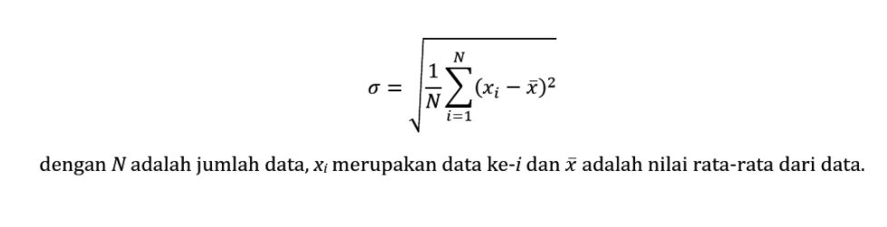

```python
# Dua buah data yang tersimpan dalam tipe list
data1 = [70, 70, 70, 100, 100, 100, 120, 120, 150, 150]
data2 = [50, 60, 60, 50, 70, 70, 100, 80, 100, 90]

# Fungsi rata-rata data
def hitung_rata_rata(data):
    jumlah = 0
    for item in data:
        jumlah += item
        rata_rata = jumlah/len(data)
    return rata_rata

# Definisikan fungsi hitung_standar_deviasi
def hitung_standar_deviasi(data):
    rata_rata_data = hitung_rata_rata(data)
    varians = 0

    for item in data:
        varians += (item - rata_rata_data) ** 2
        varians /= len(data)
        standar_deviasi = varians ** (1/2)
    return standar_deviasi

# Hitung nilai standar deviasi dari kedua data yang dimiliki
print('Standar deviasi data1:')
print(hitung_standar_deviasi(data1))
print('Standar deviasi data2:')
print(hitung_standar_deviasi(data2))
```

```
Standar deviasi data1:
14.93311056335886
Standar deviasi data2:
6.025948374480153
```

.

# TUGAS PRAKTIK 11

“Aksara, hasil kerjamu dapat pujian di rapat tadi. Terima kasih ya sudah membantu!” ujar Senja yang menghampiri mejaku setelah keluar dari ruang rapat.

Aku mengangguk. Mungkin program tadi sederhana saja, tapi bisa bermanfaat bagi yang membutuhkannya sangat membahagiakan buatku.

“Oh ya, Aksara sebelum kamu pulang bisa tolong buatkan fungsi baru lagi? Kali ini untuk menentukan nilai-rata dan standar deviasi dari data di tabel. Nanti aku kasih data di tabelnya ya.” Senja langsung menarik bangku ke sebelahku dan membuka laptop.

Ia menunjukkan data di tabelnya seperti ini:

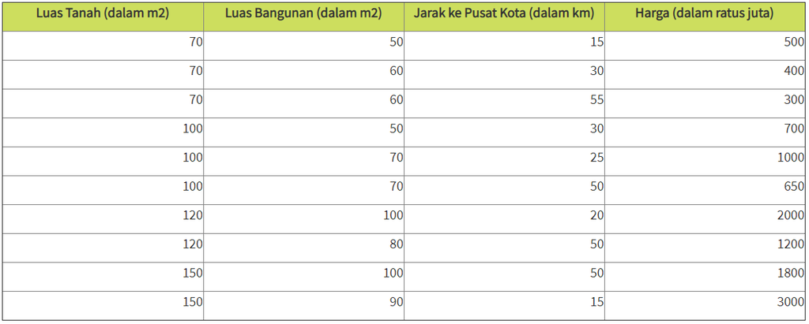

Tugas:

ari data ini, berarti aku harus menjalankan fungsi baru dengan nama variabel deksripsi_properti. Aku pun mengangkat jempol pada Senja seakan bilang, serahkan padaku.

Setelah kupelajari kembali, data ini sebenarnya telah direpresentasikan ke dalam dict dengan nama tabel_properti, kalau begitu, aku bisa mulai kodeku seperti berikut ini.

```python
# Data properti
tabel_properti = {
'luas_tanah': [70, 70, 70, 100, 100, 100, 120, 120, 150, 150],
'luas_bangunan': [50, 60, 60, 50, 70, 70, 100, 80, 100, 90],
'jarak': [15, 30, 55, 30, 25, 50, 20, 50, 50, 15],
'harga': [500, 400, 300, 700, 1000, 650, 2000, 1200, 1800, 3000]
}


# Fungsi rata-rata data
def hitung_rata_rata(data):
    jumlah = 0
    for item in data:
        jumlah += item
        rata_rata = jumlah/len(data)
    return rata_rata


# Fungsi hitung_standar_deviasi

def hitung_standar_deviasi(data):
    rata_rata_data = hitung_rata_rata(data)
    varians = 0
    for item in data:
        varians += (item - rata_rata_data) ** 2
        varians /= len(data)
        standar_deviasi = varians ** (1/2)
    return standar_deviasi


# Definisikan fungsi untuk menghitung rata-rata dan standar deviasi
# setiap kolom pada tabel_properti yang diberikan oleh key dict.
def deskripsi_properti(tabel):
    for key in tabel.keys():
        print('Rata-rata ' + key + ':')
        print(hitung_rata_rata(tabel[key]))
        print('Standar deviasi ' + key + ':')
        print(hitung_standar_deviasi(tabel[key]))
        print('')


# Panggil fungsi deskripsi_properti untuk menghitung rata-rata
# dan standar deviasi setiap kolom pada tabel_properti
deskripsi_properti(tabel_properti)
```

```
Rata-rata luas_tanah:
105.0
Standar deviasi luas_tanah:
14.93311056335886

Rata-rata luas_bangunan:
73.0
Standar deviasi luas_bangunan:
6.025948374480153

Rata-rata jarak:
34.0
Standar deviasi jarak:
6.24005184770928

Rata-rata harga:
1155.0
Standar deviasi harga:
587.0594351517378
```

.

.

# J. MANIPULASI BERKAS TEXT

## J1. Manipulasi Berkas Text

Pengolahan berkas teks pada Python tidak membutuhkan proses import dependencies lainnya seperti pada bahasa-bahasa pemrograman lainnya.

Untuk memanipulasi berkas teks pada bahasa pemrograman Python, mula-mula, kita harus membuka/ membuat berkas teks yang aku inginkan dengan menggunakan fungsi open(). Fungsi open() menerima 2 parameter, di mana parameter pertama merupakan nama dari file yang ingin dibuka/ dibuat dan mode yang berkaitan dengan aksi yang ingin dilakukan terhadap file yang telah terbuka. Sebagai contoh,

```python
file = open("hello.txt", "r")
```

argumen/ parameter "r" mengartikan bahwa file yang akan dibuka berada dalam mode “read” sehingga nantinya aku tidak dapat menambahkan/ menuliskan ulang isi tulisan dari file “hello.txt”.

Perintah ini dapat digunakan untuk menutup file yang telah aku buka.

```python
file.close()
```

Selain mode "r" yang hanya digunakan untuk membaca file, terdapat juga mode lainnya seperti:

- w: write, mode ini dapat aku gunakan untuk menulis ke dalam sebuah berkas teks, jika berkas tidak tersedia, maka Python akan secara otomatis membuat sebuah berkas baru dengan nama yang telah di spesifikasikan. Saat menulis dengan menggunakan mode ini, jika file semula tidak kosong, maka isi yang sebelumnya terdapat di dalam berkas akan terhapus.
- a: append, mode ini dapat aku gunakan untuk menambahkan isi dari sebuah berkas teks. Mode ini juga akan membuat sebuah berkas teks baru dengan nama yang telah kita spesifikasikan jika berkas teks tidak tersedia.
- w+: write+, mode ini dapat aku gunakan untuk membaca ataupun menuliskan isi dari sebuah berkas teks.
- a+: append+, mode ini dapat aku gunakan untuk membaca ataupun menambahkan isi dari sebuah berkas teks.

## J2. Membaca Berkas Text

Setelah mempelajari bagaimana membuka/ membuat sebuah berkas teks dalam Python, kita akan mempelajari sintaks untuk dapat membaca isi dari sebuah berkas. Untuk membaca isi dari sebuah teks aku dapat menggunakan potongan kode berikut.

Kita asumsikan baris-baris di bawah comment merupakan isi dari “hello.txt”.

```
Kita sedang belajar Python
Tepatnya belajar memanipulasi berkas teks
Memanipulasi berkas dengan Python sangatlah mudah!
```

#### Tugas 1

Membaca file hello.txt dengan fungsi read() dan menutup file

```python
# Membaca file hello.txt dengan fungsi read()
print(">>> Membaca file hello.txt dengan fungsi read()")
file = open("hello.txt", "r")
content = file.read()
```

```
>>> Membaca file hello.txt dengan fungsi read()
```

Perintah ini kita gunakan untuk menutup berkas setelah selesai digunakan

```python
file.close()
print(content)
```

```
Kita sedang belajar Python
Tepatnya belajar memanipulasi berkas teks
Memanipulasi berkas dengan Python sangatlah mudah!
```

Selain dapat membaca dan menampung isi dari sebuah berkas secara sekaligus menggunakan fungsi read(), kita juga dapat menggunakan fungsi readline() ataupun readlines() untuk membaca isi dari suatu berkas teks. Dengan menggunakan fungsi readline(), Python akan membaca konten dari sebuah berkas secara baris per baris, dimulai dari baris paling awal.

#### Tugas 2

Membaca file hello.txt dengan fungsi readline()

```python
# Membaca file hello.txt dengan fungsi readline()
print(">>> Membaca file hello.txt dengan fungsi readline()")
file = open("hello.txt", "r")
```

```
>>> Membaca file hello.txt dengan fungsi readline()
```

dengan menggunakan fungsi .readline() dapat aku gunakan untuk membaca isi dari file secara tersedia dalam berkas “hello.txt” baris per baris

```python
first_line = file.readline()
second_line = file.readline()
```

perintah ini kita gunakan untuk menutup berkas setelah selesai digunakan

```python
file.close()
print(first_line)
print(second_line)
```

```
Kita sedang belajar Python

Tepatnya belajar memanipulasi berkas teks
```

Fungsi readlines() akan mengembalikan sebuah list yang setiap elemennya merupakan setiap baris dalam sebuah berkas teks.

#### Tugas 4

Membaca file hello.txt dengan fungsi readlines()

```python
# Membaca file hello.txt dengan fungsi readlines()
print(">>> Membaca file hello.txt dengan fungsi readlines()")
file = open("hello.txt", "r")
```

```
>>> Membaca file hello.txt dengan fungsi readlines()
```

Dan membaca dengan fungsi readlines(),

```python
all_lines = file.readlines()
file.close()
print(all_lines)
```

```
['Kita sedang belajar Python\n', 'Tepatnya belajar memanipulasi berkas teks\n', 'Memanipulasi berkas dengan Python sangatlah mudah!']
```

#### Tugas 5

Membaca file hello.txt dengan menerapkan looping

```python
# Membaca file hello.txt dengan menerapkan looping
print(">>> Membaca file hello.txt dengan menerapkan looping")
file = open("hello.txt", "r")
```

```
>>> Membaca file hello.txt dengan menerapkan looping
```

untuk setiap baris sebagai variabel line dalam berkas dengan nama variabel file

```python
for line in file:
    print(line)
```

```
Kita sedang belajar Python

Tepatnya belajar memanipulasi berkas teks

Memanipulasi berkas dengan Python sangatlah mudah!
```

.

## J3. Menulis Berkas Text

Untuk menuliskan isi dari suatu berkas, kita dapat menggunakan fungsi write() atau writelines() yang telah disediakan oleh Python. Sebelum masuk ke dalam contoh penggunaan fungsi write() atau writelines(), penting bagi kita untuk mengingat bahwa mode yang kita spesifikasikan pada fungsi open() akan mempengaruhi bagaimana Python menuliskan isi ke dalam berkas teks. Jika kita menggunakan mode "w", maka Python akan menghapus seluruh isi dalam berkas sebelum menuliskan konten yang kita spesifikasikan.

Asumsikan baris-baris di bawah comment ini merupakan isi dari “hello.txt”

```
Kita sedang belajar Python
Tepatnya belajar memanipulasi berkas teks
Memanipulasi berkas dengan Python sangatlah mudah!
```

#### Tugas 6

Buat perintah yang digunakan untuk membuka/membuat sebuah berkas teks

```python
# Menulis ke file hello.txt
file = open("hello.txt", "w")
```

untuk setiap baris sebagai variabel line dalam berkas dengan nama variabel file

```python
file.write("Sekarang kita belajar menulis dengan menggunakan Python")
file.write("Menulis konten file dengan mode w (write).")
file.close()
```

Jika kita cek isi file text, maka akan berubah.

```python
# Membaca file hello.txt dengan fungsi readlines()

file = open("hello.txt", "r")

all_lines = file.readlines()
file.close()
print(all_lines)
```

```
['Sekarang kita belajar menulis dengan menggunakan PythonMenulis konten file dengan mode w (write).']
```

Ketika kita menulis pada berkas teks menggunakan mode "a", Python tidak akan menghapus isi dalam berkas dan hanya akan menambahkan konten. kita mempelajari contoh berikut untuk memahami penggunaan fungsi write() dan writelines()

#### Tugas 7

asumsikan baris-baris di bawah comment ini merupakan isi dari “hello.txt”

```
Kita sedang belajar Python
Tepatnya belajar memanipulasi berkas teks
Memanipulasi berkas dengan Python sangatlah mudah!
```

Perintah ini kita gunakan untuk membuka/membuat sebuah berkas teks dengan menggunakan mode “a”, untuk menambahkan beberapa baris pada berkas teks setelah isi dari berkas awalnya

```python
# Menulis ke file dengan mode append
file = open("hello.txt", "a")
```

```python
file.writelines([
" Sekarang kita belajar menulis dengan menggunakan Python",
" Menulis konten file dengan mode a (append)."
])
file.close()
```

Jika kita cek

```python
# Membaca file hello.txt dengan fungsi readlines()

file = open("hello.txt", "r")

all_lines = file.readlines()
file.close()
print(all_lines)
```

[output not shown]

.

.

# K. LIBRARY MATEMATIKA

Salah satu keunikan Python adalah library yang dimilikinya karena dapat di-extend dengan library yang didefinisikan oleh pengguna Python, selain dari library bawaan (built-in) yang dimilikinya. Untuk membuat library yang didefinisikan oleh pengguna umumnya dilakukan dengan menggunakan teknik pemograman berorientasi obyek (object oriented programming).

Tentunya secara dasar, Python tidak dapat digunakan untuk pengolahan data, komputasi saintifik, machine learning dan bahkan sistem cerdas. Melalui pengembang library tentunya aku memiliki akses ke keperluan atau bidang tersebut. Library ini dapat diinstal melalui command pip yang bersumber dari webnya python package index.

Bagi yang pernah menggunakan Matlab pasti tahu ada toolbox tertentu misal untuk optimasi, pengolahan sinyal, dll. Jadi toolbox di Matlab itu ekuivalen dengan library pada Python. Bahasa pemograman lain seperti R, PHP, GO, Java dsb tentu juga punya apakah namanya tetap library atau framework.

Untuk memanggil library pada python, aku dapat menggunakan syntax:

[output not shown]

adalah nama library yang akan diimport untuk dapat digunakan dalam kode program yang disusun, baik library bawaan (built-in), library yang tersedia di webnya python package index atau dikembangkan sendiri.

Python adalah salah satu bahasa yang paling diminati untuk pengolahan data secara matematis. Untuk menggunakan fungsi-fungsi matematis yang telah disediakan oleh bahasa Python, aku dapat melakukan proses import library math seperti pada potongan kode berikut,

```
import math
```

Di dalam library math kita mempelajari berbagai fungsi, beberapa diantaranya dapat dilihat pada tabel di bawah ini.

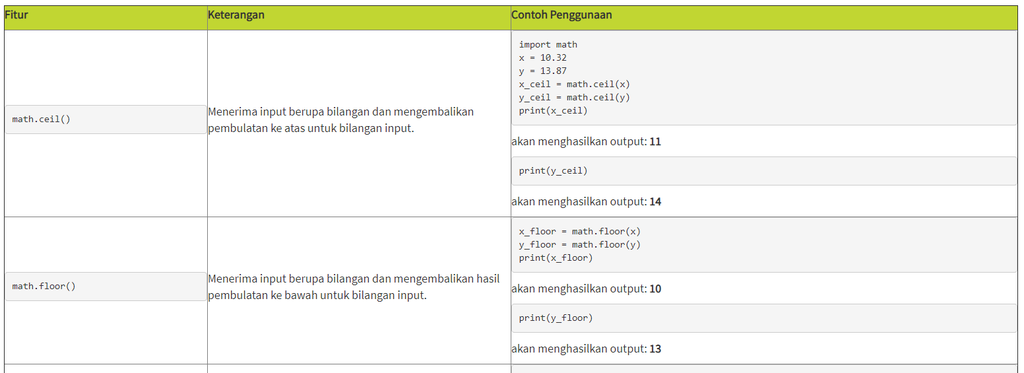

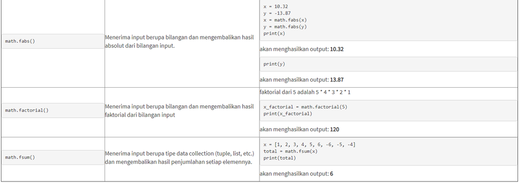

```python
# Import library math
import math

# Fungsi math.ceil()
print(">>> Fungsi math.ceil()")
x = 10.32
y = 13.87
x_ceil = math.ceil(x)
y_ceil = math.ceil(y)
print(x_ceil)
print(y_ceil)

# Fungsi math.floor()
print(">>> Fungsi math.floor()")
x_floor = math.floor(x)
y_floor = math.floor(y)
print(x_floor)
print(y_floor)

# Fungsi math.fabs()
print(">>> Fungsi math.fabs()")
x = 10.32
y = -13.87
x = math.fabs(x)
y = math.fabs(y)
print(x)
print(y)

# Fungsi math.factorial()
print(">>> Fungsi math.factorial()")
x_factorial = math.factorial(5)
print(x_factorial)

# Fungsi math.fsum()
print(">>> Fungsi math.fsum()")
x = [1, 2, 3, 4, 5, 6, -6, -5, -4]
total = math.fsum(x)
print(total)
```

```
>>> Fungsi math.ceil()
11
14
>>> Fungsi math.floor()
10
13
>>> Fungsi math.fabs()
10.32
13.87
>>> Fungsi math.factorial()
120
>>> Fungsi math.fsum()
6.0
```

.

Kita masih melanjutkan bagian terakhir dari (bulit-in) library matematika pada Python yang dapat digunakan untuk perhitungan matematis.

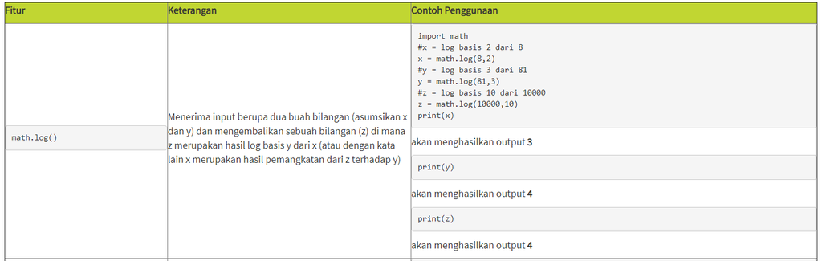

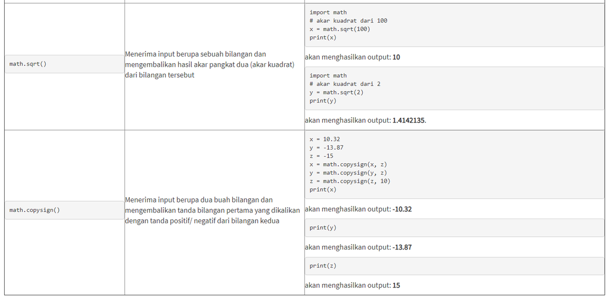

```python
# Import library math
import math

# Fungsi math.log()
print(">>> Fungsi math.log()")
# x = log basis 2 dari 8
x = math.log(8, 2)
# y = log basis 3 dari 81
y = math.log(81, 3)
# z = log basis 10 dari 10000
z = math.log(10000,10)
print(x)
print(y)
print(z)

# Fungsi math.sqrt()
print(">>> Fungsi math.sqrt()")
# akar kuadrat dari 100
x = math.sqrt(100)
print(x)
# akar kuadrat dari 2
y = math.sqrt(2)
print(y)

# Fungsi math.copysign()
print(">>> Fungsi math.copysign()")
x = 10.32
y = -13.87
z = -15
x = math.copysign(x, z)
y = math.copysign(y, z)
z = math.copysign(z, 10)
print(x)
print(y)
print(z)
```

```
>>> Fungsi math.log()
3.0
4.0
4.0
>>> Fungsi math.sqrt()
10.0
1.4142135623730951
>>> Fungsi math.copysign()
-10.32
-13.87
15.0
```